# final-submission

Mike Fanor mfanor1@student.gsu.edu 002-27-2383

Ayobami Loye aloye1@student.gsu.edu 002-18-5419

Kyle Hodge khodge9@student.gsu.edu 900-89-3991

Minhaj Shujauddin Mshujauddin1@student.gsu.edu 002-22-5574

```python
from sklearn.model_selection import train_test_split
import pandas as pd, warnings

warnings.filterwarnings(action='ignore')
```

```python
white_wine = pd.read_csv('winequality-white.csv', sep=';')
red_wine = pd.read_csv('winequality-red.csv', sep=';')
wine_data = pd.concat([white_wine, red_wine], ignore_index=True)
```

```python
wine_data
```

|  | fixed acidity | volatile acidity | citric acid | residual sugar | chlorides | free sulfur dioxide | total sulfur dioxide | density | pH | sulphates | alcohol | quality |
| --- | --- | --- | --- | --- | --- | --- | --- | --- | --- | --- | --- | --- |
| 0 | 7.0 | 0.270 | 0.36 | 20.7 | 0.045 | 45.0 | 170.0 | 1.00100 | 3.00 | 0.45 | 8.8 | 6 |
| 1 | 6.3 | 0.300 | 0.34 | 1.6 | 0.049 | 14.0 | 132.0 | 0.99400 | 3.30 | 0.49 | 9.5 | 6 |
| 2 | 8.1 | 0.280 | 0.40 | 6.9 | 0.050 | 30.0 | 97.0 | 0.99510 | 3.26 | 0.44 | 10.1 | 6 |
| 3 | 7.2 | 0.230 | 0.32 | 8.5 | 0.058 | 47.0 | 186.0 | 0.99560 | 3.19 | 0.40 | 9.9 | 6 |
| 4 | 7.2 | 0.230 | 0.32 | 8.5 | 0.058 | 47.0 | 186.0 | 0.99560 | 3.19 | 0.40 | 9.9 | 6 |
| ... | ... | ... | ... | ... | ... | ... | ... | ... | ... | ... | ... | ... |
| 6492 | 6.2 | 0.600 | 0.08 | 2.0 | 0.090 | 32.0 | 44.0 | 0.99490 | 3.45 | 0.58 | 10.5 | 5 |
| 6493 | 5.9 | 0.550 | 0.10 | 2.2 | 0.062 | 39.0 | 51.0 | 0.99512 | 3.52 | 0.76 | 11.2 | 6 |
| 6494 | 6.3 | 0.510 | 0.13 | 2.3 | 0.076 | 29.0 | 40.0 | 0.99574 | 3.42 | 0.75 | 11.0 | 6 |
| 6495 | 5.9 | 0.645 | 0.12 | 2.0 | 0.075 | 32.0 | 44.0 | 0.99547 | 3.57 | 0.71 | 10.2 | 5 |
| 6496 | 6.0 | 0.310 | 0.47 | 3.6 | 0.067 | 18.0 | 42.0 | 0.99549 | 3.39 | 0.66 | 11.0 | 6 |

6497 rows × 12 columns

## EDA

```python
wine_data.info()
```

```
<class 'pandas.core.frame.DataFrame'>
RangeIndex: 6497 entries, 0 to 6496
Data columns (total 12 columns):
fixed acidity           6497 non-null float64
volatile acidity        6497 non-null float64
citric acid             6497 non-null float64
residual sugar          6497 non-null float64
chlorides               6497 non-null float64
free sulfur dioxide     6497 non-null float64
total sulfur dioxide    6497 non-null float64
density                 6497 non-null float64
pH                      6497 non-null float64
sulphates               6497 non-null float64
alcohol                 6497 non-null float64
quality                 6497 non-null int64
dtypes: float64(11), int64(1)
memory usage: 609.2 KB
```

```python
# splitting original data into features and labels (for model evaluation later on)
original_X = wine_data.iloc[:, :-1]
original_y = wine_data.iloc[:, -1]
```

```python
wine_data.describe()
```

|  | fixed acidity | volatile acidity | citric acid | residual sugar | chlorides | free sulfur dioxide | total sulfur dioxide | density | pH | sulphates | alcohol | quality |
| --- | --- | --- | --- | --- | --- | --- | --- | --- | --- | --- | --- | --- |
| count | 6497.000000 | 6497.000000 | 6497.000000 | 6497.000000 | 6497.000000 | 6497.000000 | 6497.000000 | 6497.000000 | 6497.000000 | 6497.000000 | 6497.000000 | 6497.000000 |
| mean | 7.215307 | 0.339666 | 0.318633 | 5.443235 | 0.056034 | 30.525319 | 115.744574 | 0.994697 | 3.218501 | 0.531268 | 10.491801 | 5.818378 |
| std | 1.296434 | 0.164636 | 0.145318 | 4.757804 | 0.035034 | 17.749400 | 56.521855 | 0.002999 | 0.160787 | 0.148806 | 1.192712 | 0.873255 |
| min | 3.800000 | 0.080000 | 0.000000 | 0.600000 | 0.009000 | 1.000000 | 6.000000 | 0.987110 | 2.720000 | 0.220000 | 8.000000 | 3.000000 |
| 25% | 6.400000 | 0.230000 | 0.250000 | 1.800000 | 0.038000 | 17.000000 | 77.000000 | 0.992340 | 3.110000 | 0.430000 | 9.500000 | 5.000000 |
| 50% | 7.000000 | 0.290000 | 0.310000 | 3.000000 | 0.047000 | 29.000000 | 118.000000 | 0.994890 | 3.210000 | 0.510000 | 10.300000 | 6.000000 |
| 75% | 7.700000 | 0.400000 | 0.390000 | 8.100000 | 0.065000 | 41.000000 | 156.000000 | 0.996990 | 3.320000 | 0.600000 | 11.300000 | 6.000000 |
| max | 15.900000 | 1.580000 | 1.660000 | 65.800000 | 0.611000 | 289.000000 | 440.000000 | 1.038980 | 4.010000 | 2.000000 | 14.900000 | 9.000000 |

### Class distribution

```python
wine_data.iloc[:, -1].value_counts()
```

```
6    2836
5    2138
7    1079
4     216
8     193
3      30
9       5
Name: quality, dtype: int64
```

```python
import matplotlib.pyplot as plt, seaborn as sns
```

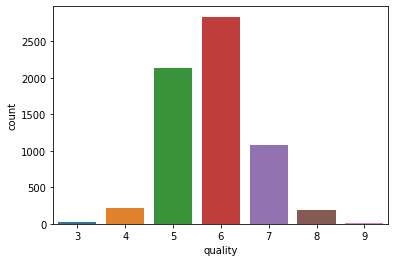

```python
sns.countplot('quality', data=wine_data)
```

Clearly there is a large class imbalance.

For this, we will oversample each class by the same amount.

### PCA for visualization

```python
from sklearn.preprocessing import MinMaxScaler
from sklearn.decomposition import PCA
```

```python
mm = MinMaxScaler()
```

```python
def plot_data_with_PCA(data, scaler):
    data_X = data.iloc[:, :-1]
    data_y = data.iloc[:, -1]

    scaled_feats = scaler.fit_transform(data_X)
    scaled_data = pd.DataFrame(scaled_feats)
    scaled_data['output'] = data_y
    scaled_data.columns = data.columns

    pca = PCA(n_components=2)
    components = pca.fit_transform(scaled_feats)
    pca_df = pd.DataFrame(components)
    pca_df.columns = ['component1', 'component2']
    print('Information retained from component1', pca.explained_variance_ratio_[0])
    print('Information retained from component2', pca.explained_variance_ratio_[1])

    targets = list(data_y.unique())
    colors = ['r', 'g', 'b', 'y', 'c', 'k', 'm']

    for target, color in zip(targets, colors):
        idx = data.quality == target

        plt.scatter(pca_df.loc[idx, 'component1'],
                    pca_df.loc[idx, 'component2'],
                    c = color,
                    s = 50)
```

##### Original dataset PCA visualization

```
Information retained from component1 0.3201497030488873
Information retained from component2 0.23518497325114593
```

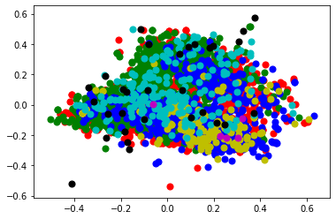

```python
plot_data_with_PCA(wine_data, mm)
```

### Boxplots for outlier detection and distribution plots (per feature)

##### Fixed acidity

```
{'whiskers': [<matplotlib.lines.Line2D at 0x126d855d0>,
 'caps': [<matplotlib.lines.Line2D at 0x126d8f090>,
 'boxes': [<matplotlib.lines.Line2D at 0x126d7a990>],
 'medians': [<matplotlib.lines.Line2D at 0x126d8fad0>],
 'fliers': [<matplotlib.lines.Line2D at 0x1220ed250>],
 'means': []}
```

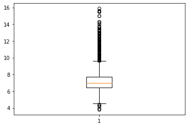

```python
plt.boxplot(wine_data.iloc[:, 0])
```

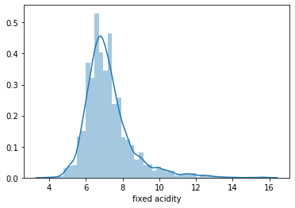

```python
sns.distplot(wine_data.iloc[:, 0])
```

##### Volatile acidity

```
{'whiskers': [<matplotlib.lines.Line2D at 0x126f240d0>,
 'caps': [<matplotlib.lines.Line2D at 0x126f2e750>,
 'boxes': [<matplotlib.lines.Line2D at 0x126f24090>],
 'medians': [<matplotlib.lines.Line2D at 0x126f341d0>],
 'fliers': [<matplotlib.lines.Line2D at 0x126f346d0>],
 'means': []}
```

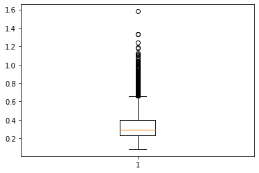

```python
plt.boxplot(wine_data.iloc[:, 1])
```

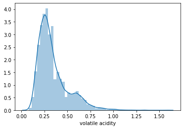

```python
sns.distplot(wine_data.iloc[:, 1])
```

##### Citric acid

```
{'whiskers': [<matplotlib.lines.Line2D at 0x1270ae2d0>,
 'caps': [<matplotlib.lines.Line2D at 0x127125950>,
 'boxes': [<matplotlib.lines.Line2D at 0x1270ae290>],
 'medians': [<matplotlib.lines.Line2D at 0x12712d3d0>],
 'fliers': [<matplotlib.lines.Line2D at 0x12712d8d0>],
 'means': []}
```

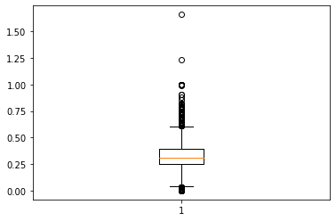

```python
plt.boxplot(wine_data.iloc[:, 2])
```

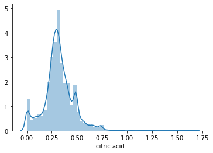

```python
sns.distplot(wine_data.iloc[:, 2])
```

##### Residual Sugar

```
{'whiskers': [<matplotlib.lines.Line2D at 0x1272342d0>,
 'caps': [<matplotlib.lines.Line2D at 0x12723b950>,
 'boxes': [<matplotlib.lines.Line2D at 0x127234290>],
 'medians': [<matplotlib.lines.Line2D at 0x1272413d0>],
 'fliers': [<matplotlib.lines.Line2D at 0x1272418d0>],
 'means': []}
```

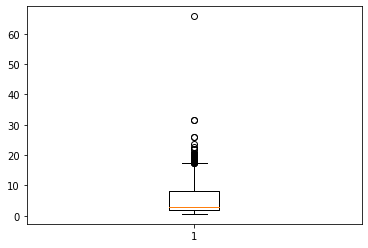

```python
plt.boxplot(wine_data.iloc[:, 3])
```

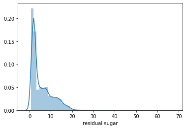

```python
sns.distplot(wine_data.iloc[:, 3])
```

##### Chlorides

```
{'whiskers': [<matplotlib.lines.Line2D at 0x1273f1c50>,
 'caps': [<matplotlib.lines.Line2D at 0x1274032d0>,
 'boxes': [<matplotlib.lines.Line2D at 0x1273f1c10>],
 'medians': [<matplotlib.lines.Line2D at 0x127403d10>],
 'fliers': [<matplotlib.lines.Line2D at 0x12740a250>],
 'means': []}
```

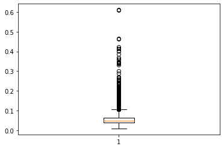

```python
plt.boxplot(wine_data.iloc[:, 4])
```

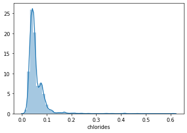

```python
sns.distplot(wine_data.iloc[:, 4])
```

##### Free sulfur dioxide

```
{'whiskers': [<matplotlib.lines.Line2D at 0x1275cf950>,
 'caps': [<matplotlib.lines.Line2D at 0x127646550>,
 'boxes': [<matplotlib.lines.Line2D at 0x1275cf910>],
 'medians': [<matplotlib.lines.Line2D at 0x1276508d0>],
 'fliers': [<matplotlib.lines.Line2D at 0x127650d90>],
 'means': []}
```

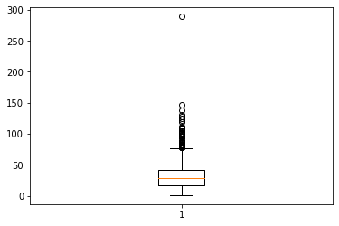

```python
plt.boxplot(wine_data.iloc[:, 5])
```

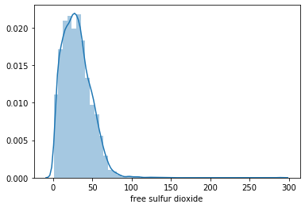

```python
sns.distplot(wine_data.iloc[:, 5])
```

##### Total sulfur dioxide

```
{'whiskers': [<matplotlib.lines.Line2D at 0x1278208d0>,
 'caps': [<matplotlib.lines.Line2D at 0x12782ced0>,
 'boxes': [<matplotlib.lines.Line2D at 0x127820890>],
 'medians': [<matplotlib.lines.Line2D at 0x1278a5950>],
 'fliers': [<matplotlib.lines.Line2D at 0x1278a5e50>],
 'means': []}
```

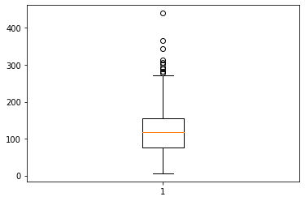

```python
plt.boxplot(wine_data.iloc[:, 6])
```

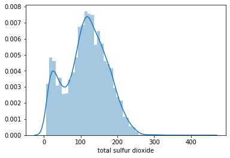

```python
sns.distplot(wine_data.iloc[:, 6])
```

##### Density

```
{'whiskers': [<matplotlib.lines.Line2D at 0x127ad8590>,
 'caps': [<matplotlib.lines.Line2D at 0x127adfc10>,
 'boxes': [<matplotlib.lines.Line2D at 0x127ad8550>],
 'medians': [<matplotlib.lines.Line2D at 0x127ae5690>],
 'fliers': [<matplotlib.lines.Line2D at 0x127ae5b90>],
 'means': []}
```

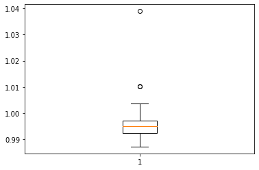

```python
plt.boxplot(wine_data.iloc[:, 7])
```

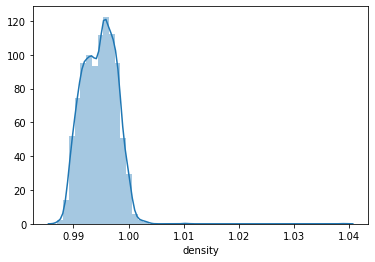

```python
sns.distplot(wine_data.iloc[:, 7])
```

##### pH

```
{'whiskers': [<matplotlib.lines.Line2D at 0x127ca4a10>,
 'caps': [<matplotlib.lines.Line2D at 0x127d240d0>,
 'boxes': [<matplotlib.lines.Line2D at 0x127ca49d0>],
 'medians': [<matplotlib.lines.Line2D at 0x127d24b10>],
 'fliers': [<matplotlib.lines.Line2D at 0x127d2c050>],
 'means': []}
```

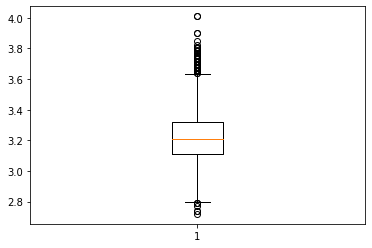

```python
plt.boxplot(wine_data.iloc[:, 8])
```

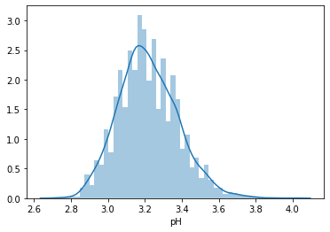

```python
sns.distplot(wine_data.iloc[:, 8])
```

##### Sulphates

```
{'whiskers': [<matplotlib.lines.Line2D at 0x127eec090>,
 'caps': [<matplotlib.lines.Line2D at 0x127ef1710>,
 'boxes': [<matplotlib.lines.Line2D at 0x127eec050>],
 'medians': [<matplotlib.lines.Line2D at 0x127efa190>],
 'fliers': [<matplotlib.lines.Line2D at 0x127efa690>],
 'means': []}
```

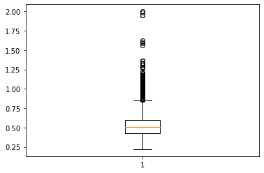

```python
plt.boxplot(wine_data.iloc[:, 9])
```

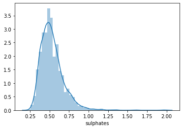

```python
sns.distplot(wine_data.iloc[:, 9])
```

##### Alcohol

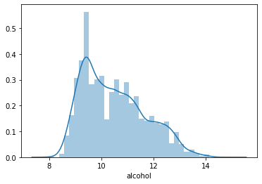

```python
sns.distplot(wine_data.iloc[:, 10])
```

```
{'whiskers': [<matplotlib.lines.Line2D at 0x128273c10>,
 'caps': [<matplotlib.lines.Line2D at 0x1282832d0>,
 'boxes': [<matplotlib.lines.Line2D at 0x128273bd0>],
 'medians': [<matplotlib.lines.Line2D at 0x128283d10>],
 'fliers': [<matplotlib.lines.Line2D at 0x12828c250>],
 'means': []}
```

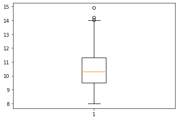

```python
plt.boxplot(wine_data.iloc[:, 10])
```

## Resampling the data

(Training on resampled data and testing on unresampled data)

**Resampling is STRICTLY for TRAINING purposes

```python
from imblearn.under_sampling import NearMiss
from imblearn.over_sampling import SMOTE

from sklearn.ensemble import RandomForestClassifier
from sklearn import metrics
```

```python
original_y.value_counts()
```

```
6    2836
5    2138
7    1079
4     216
8     193
3      30
9       5
Name: quality, dtype: int64
```

```python
over_samp = {
    9: 5+4000,
    3: 30+4000,
    8: 193+4000,
    4: 216+4000,
    7: 1079+4000,
    5: 2138+4000,
    6: 2836+4000
}

smt = SMOTE(sampling_strategy=over_samp,
            k_neighbors=min(original_y.value_counts())-1)
```

Oversampling by a constant amount is much better than altering the ratio of the original daataset. It's as if we have the original dataset but with more information.

#### Oversampling

```python
X_for_resample, y_for_resample = smt.fit_sample(original_X, original_y)
```

```python
resampled_data = pd.concat([pd.DataFrame(X_for_resample), pd.DataFrame(y_for_resample)], axis=1)
resampled_data.columns = wine_data.columns
resampled_data
```

|  | fixed acidity | volatile acidity | citric acid | residual sugar | chlorides | free sulfur dioxide | total sulfur dioxide | density | pH | sulphates | alcohol | quality |
| --- | --- | --- | --- | --- | --- | --- | --- | --- | --- | --- | --- | --- |
| 0 | 7.000000 | 0.270000 | 0.360000 | 20.700000 | 0.045000 | 45.000000 | 170.000000 | 1.001000 | 3.000000 | 0.450000 | 8.800000 | 6 |
| 1 | 6.300000 | 0.300000 | 0.340000 | 1.600000 | 0.049000 | 14.000000 | 132.000000 | 0.994000 | 3.300000 | 0.490000 | 9.500000 | 6 |
| 2 | 8.100000 | 0.280000 | 0.400000 | 6.900000 | 0.050000 | 30.000000 | 97.000000 | 0.995100 | 3.260000 | 0.440000 | 10.100000 | 6 |
| 3 | 7.200000 | 0.230000 | 0.320000 | 8.500000 | 0.058000 | 47.000000 | 186.000000 | 0.995600 | 3.190000 | 0.400000 | 9.900000 | 6 |
| 4 | 7.200000 | 0.230000 | 0.320000 | 8.500000 | 0.058000 | 47.000000 | 186.000000 | 0.995600 | 3.190000 | 0.400000 | 9.900000 | 6 |
| ... | ... | ... | ... | ... | ... | ... | ... | ... | ... | ... | ... | ... |
| 34492 | 8.743057 | 0.268215 | 0.457139 | 9.100841 | 0.034465 | 28.535414 | 122.036815 | 0.995804 | 3.230340 | 0.452861 | 10.846178 | 9 |
| 34493 | 6.634289 | 0.360000 | 0.295715 | 1.897172 | 0.020657 | 27.771803 | 88.886100 | 0.989667 | 3.395141 | 0.581426 | 12.434289 | 9 |
| 34494 | 7.278115 | 0.248126 | 0.412817 | 2.081257 | 0.031406 | 28.625137 | 128.436607 | 0.990448 | 3.316566 | 0.455623 | 12.662514 | 9 |
| 34495 | 7.181845 | 0.254544 | 0.454534 | 2.145436 | 0.031727 | 29.908728 | 120.093269 | 0.990368 | 3.345446 | 0.436369 | 12.790873 | 9 |
| 34496 | 8.710497 | 0.263126 | 0.429379 | 8.629572 | 0.034084 | 27.770880 | 127.436793 | 0.995522 | 3.218330 | 0.464582 | 10.881151 | 9 |

34497 rows × 12 columns

```python
resampled_features = resampled_data.iloc[:, :-1]
resampled_labels = resampled_data.iloc[:, -1]
```

### Resampled dataset PCA visualization

```
Information retained from component1 0.33380085819044386
Information retained from component2 0.2792865535628892
```

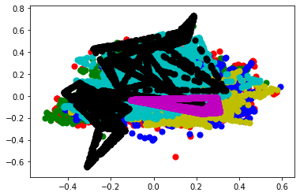

```python
plot_data_with_PCA(resampled_data, mm)
```

### Correlation of original data and resampled data

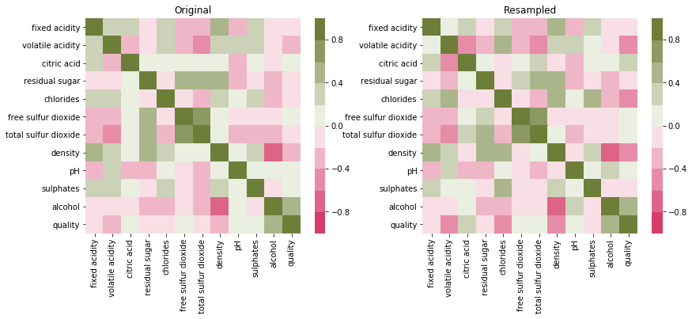

```python
fig1 = plt.figure(figsize=(14,5))
ax1 = fig1.add_subplot(121, title='Original')
ax2 = fig1.add_subplot(122, title='Resampled')

sns.heatmap(
    wine_data.corr(),
    vmin=-1,
    vmax=1,
    center=0,
    cmap=sns.diverging_palette(0, 100, n=10),
    square=True,
    ax=ax1
)

sns.heatmap(
    resampled_data.corr(),
    vmin=-1,
    vmax=1,
    center=0,
    cmap=sns.diverging_palette(0, 100, n=10),
    square=True,
    ax=ax2,
)
```

As shown, the correlation values, specifically for the output (quality), became a little stronger with the resampled data.

### Resampled Distributions

##### Fixed acidity

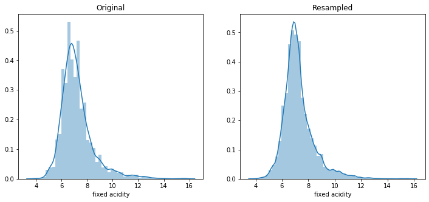

```python
fig1 = plt.figure(figsize=(12,5))
ax1 = fig1.add_subplot(121, title='Original')
ax2 = fig1.add_subplot(122, title='Resampled')

sns.distplot(wine_data.iloc[:, 0], ax=ax1)
sns.distplot(resampled_data.iloc[:, 0], ax=ax2)
```

##### Volatile acidity

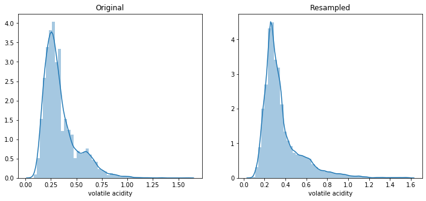

```python
fig1 = plt.figure(figsize=(12,5))
ax1 = fig1.add_subplot(121, title='Original')
ax2 = fig1.add_subplot(122, title='Resampled')

sns.distplot(wine_data.iloc[:, 1], ax=ax1)
sns.distplot(resampled_data.iloc[:, 1], ax=ax2)
```

##### Citric acid

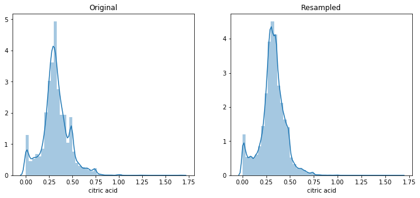

```python
fig1 = plt.figure(figsize=(12,5))
ax1 = fig1.add_subplot(121, title='Original')
ax2 = fig1.add_subplot(122, title='Resampled')

sns.distplot(wine_data.iloc[:, 2], ax=ax1)
sns.distplot(resampled_data.iloc[:, 2], ax=ax2)
```

##### Residual Sugar

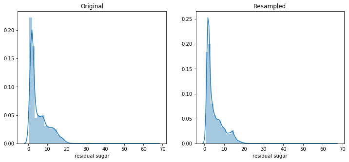

```python
fig1 = plt.figure(figsize=(12,5))
ax1 = fig1.add_subplot(121, title='Original')
ax2 = fig1.add_subplot(122, title='Resampled')

sns.distplot(wine_data.iloc[:, 3], ax=ax1)
sns.distplot(resampled_data.iloc[:, 3], ax=ax2)
```

##### Chlorides

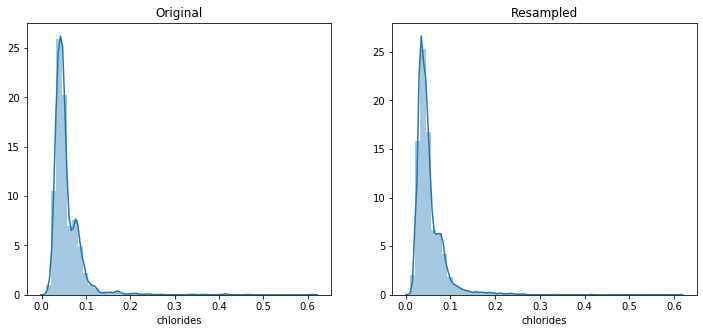

```python
fig1 = plt.figure(figsize=(12,5))
ax1 = fig1.add_subplot(121, title='Original')
ax2 = fig1.add_subplot(122, title='Resampled')

sns.distplot(wine_data.iloc[:, 4], ax=ax1)
sns.distplot(resampled_data.iloc[:, 4], ax=ax2)
```

##### Free sulfur dioxide

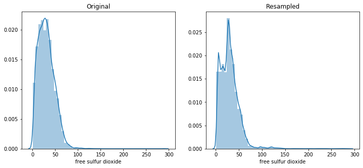

```python
fig1 = plt.figure(figsize=(12,5))
ax1 = fig1.add_subplot(121, title='Original')
ax2 = fig1.add_subplot(122, title='Resampled')

sns.distplot(wine_data.iloc[:, 5], ax=ax1)
sns.distplot(resampled_data.iloc[:, 5], ax=ax2)
```

##### Total sulfur dioxide

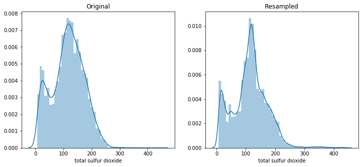

```python
fig1 = plt.figure(figsize=(12,5))
ax1 = fig1.add_subplot(121, title='Original')
ax2 = fig1.add_subplot(122, title='Resampled')

sns.distplot(wine_data.iloc[:, 6], ax=ax1)
sns.distplot(resampled_data.iloc[:, 6], ax=ax2)
```

##### Density

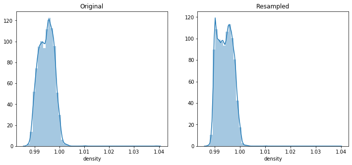

```python
fig1 = plt.figure(figsize=(12,5))
ax1 = fig1.add_subplot(121, title='Original')
ax2 = fig1.add_subplot(122, title='Resampled')

sns.distplot(wine_data.iloc[:, 7], ax=ax1)
sns.distplot(resampled_data.iloc[:, 7], ax=ax2)
```

##### pH

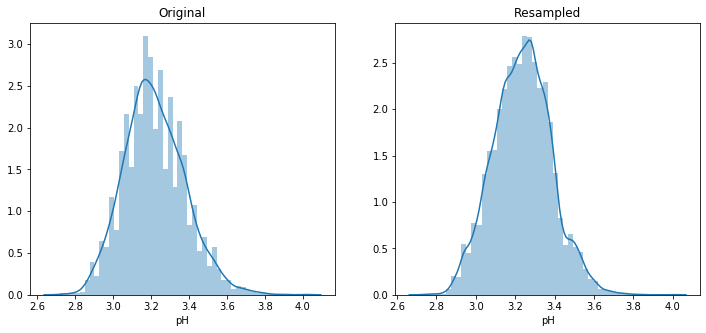

```python
fig1 = plt.figure(figsize=(12,5))
ax1 = fig1.add_subplot(121, title='Original')
ax2 = fig1.add_subplot(122, title='Resampled')

sns.distplot(wine_data.iloc[:, 8], ax=ax1)
sns.distplot(resampled_data.iloc[:, 8], ax=ax2)
```

##### Sulphates

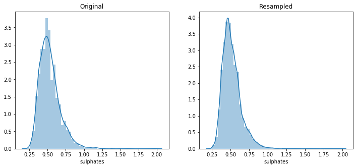

```python
fig1 = plt.figure(figsize=(12,5))
ax1 = fig1.add_subplot(121, title='Original')
ax2 = fig1.add_subplot(122, title='Resampled')

sns.distplot(wine_data.iloc[:, 9], ax=ax1)
sns.distplot(resampled_data.iloc[:, 9], ax=ax2)
```

##### Alcohol

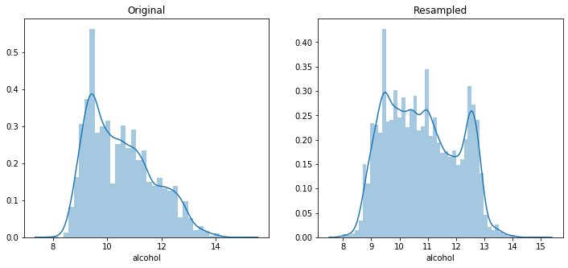

```python
fig1 = plt.figure(figsize=(12,5))
ax1 = fig1.add_subplot(121, title='Original')
ax2 = fig1.add_subplot(122, title='Resampled')

sns.distplot(wine_data.iloc[:, 10], ax=ax1)
sns.distplot(resampled_data.iloc[:, 10], ax=ax2)
```

## Feature selection

note: correlation is the same for raw data and standardized data.

```python
from sklearn.feature_selection import SelectKBest
from sklearn.feature_selection import f_regression
import json
```

```python
def best_correlations(data):
    all_feature_correlations = data.corr().iloc[:-1, -1]
    all_feature_correlations = all_feature_correlations.to_json()
    all_feature_correlations = json.loads(all_feature_correlations)

    selected_feature_correlations = {}

    for k, v in all_feature_correlations.items():
        if v < -0.2 or v > 0.2:
            selected_feature_correlations[k] = v

    return selected_feature_correlations
```

```python
resampled_data.corr().quality
```

```
fixed acidity          -0.136814
volatile acidity       -0.398845
citric acid             0.250138
residual sugar         -0.039178
chlorides              -0.400037
free sulfur dioxide     0.088797
total sulfur dioxide    0.023789
density                -0.478886
pH                      0.060902
sulphates              -0.049973
alcohol                 0.582151
quality                 1.000000
Name: quality, dtype: float64
```

```python
best_resampled_corrs = best_correlations(resampled_data)
```

```python
best_resampled_corrs
```

```
{'volatile acidity': -0.39884469,
 'citric acid': 0.2501380323,
 'chlorides': -0.4000370942,
 'density': -0.4788857707,
 'alcohol': 0.5821506815}
```

note: Using SelectKBest (pearson correlation feature selection) is a bit unnecessary since we already implemented it manually.

The purpose of selected_feature_correlations is to know the total number of usable/best features.

```python
k_best = SelectKBest(score_func=f_regression, k=len(best_resampled_corrs))
```

## Reduce the original and resampled datasets for model evaluation

To evaluate an algorithm's model on feature-selected original data, it must be trained on feature-selected resampled data first.

##### reduced original data

```python
selected_original_features = k_best.fit_transform(original_X, original_y)
```

```python
reduced_original_data = pd.DataFrame(selected_original_features)
reduced_original_data.columns = list(best_resampled_corrs.keys())
reduced_original_data['quality'] = original_y
```

```python
reduced_original_data
```

|  | volatile acidity | citric acid | chlorides | density | alcohol | quality |
| --- | --- | --- | --- | --- | --- | --- |
| 0 | 0.270 | 0.36 | 0.045 | 1.00100 | 8.8 | 6 |
| 1 | 0.300 | 0.34 | 0.049 | 0.99400 | 9.5 | 6 |
| 2 | 0.280 | 0.40 | 0.050 | 0.99510 | 10.1 | 6 |
| 3 | 0.230 | 0.32 | 0.058 | 0.99560 | 9.9 | 6 |
| 4 | 0.230 | 0.32 | 0.058 | 0.99560 | 9.9 | 6 |
| ... | ... | ... | ... | ... | ... | ... |
| 6492 | 0.600 | 0.08 | 0.090 | 0.99490 | 10.5 | 5 |
| 6493 | 0.550 | 0.10 | 0.062 | 0.99512 | 11.2 | 6 |
| 6494 | 0.510 | 0.13 | 0.076 | 0.99574 | 11.0 | 6 |
| 6495 | 0.645 | 0.12 | 0.075 | 0.99547 | 10.2 | 5 |
| 6496 | 0.310 | 0.47 | 0.067 | 0.99549 | 11.0 | 6 |

6497 rows × 6 columns

```python
reduced_original_X = reduced_original_data.iloc[:, :-1]
reduced_original_y = reduced_original_data.iloc[:, -1]
```

##### reduced resampled data

```python
selected_resampled_features = k_best.fit_transform(resampled_features, resampled_labels)
```

```python
reduced_resampled_data = pd.DataFrame(selected_resampled_features)
reduced_resampled_data.columns = list(best_resampled_corrs.keys())
reduced_resampled_data['quality'] = resampled_labels
```

```python
reduced_resampled_data
```

|  | volatile acidity | citric acid | chlorides | density | alcohol | quality |
| --- | --- | --- | --- | --- | --- | --- |
| 0 | 0.270000 | 0.360000 | 0.045000 | 1.001000 | 8.800000 | 6 |
| 1 | 0.300000 | 0.340000 | 0.049000 | 0.994000 | 9.500000 | 6 |
| 2 | 0.280000 | 0.400000 | 0.050000 | 0.995100 | 10.100000 | 6 |
| 3 | 0.230000 | 0.320000 | 0.058000 | 0.995600 | 9.900000 | 6 |
| 4 | 0.230000 | 0.320000 | 0.058000 | 0.995600 | 9.900000 | 6 |
| ... | ... | ... | ... | ... | ... | ... |
| 34492 | 0.268215 | 0.457139 | 0.034465 | 0.995804 | 10.846178 | 9 |
| 34493 | 0.360000 | 0.295715 | 0.020657 | 0.989667 | 12.434289 | 9 |
| 34494 | 0.248126 | 0.412817 | 0.031406 | 0.990448 | 12.662514 | 9 |
| 34495 | 0.254544 | 0.454534 | 0.031727 | 0.990368 | 12.790873 | 9 |
| 34496 | 0.263126 | 0.429379 | 0.034084 | 0.995522 | 10.881151 | 9 |

34497 rows × 6 columns

```python
reduced_resampled_features = reduced_resampled_data.iloc[:, :-1]
reduced_resampled_labels = reduced_resampled_data.iloc[:, -1]
```

##### Reduced dataset PCA visualization

```
Information retained from component1 0.5896374313589569
Information retained from component2 0.28845953037997024
```

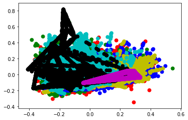

```python
plot_data_with_PCA(reduced_resampled_data, mm)
```

## Testing various algorithms with cross-validation

##### May not be able to do cross-validation with the new approach of training on resampled data and testing on original data

```python
from sklearn.linear_model import LinearRegression, LogisticRegression
from sklearn.ensemble import RandomForestRegressor, RandomForestClassifier
from sklearn.naive_bayes import GaussianNB
from sklearn.neighbors import KNeighborsClassifier
from sklearn.tree import DecisionTreeRegressor, DecisionTreeClassifier

from sklearn.model_selection import cross_val_score
```

```python
# # datasets = {'original': (original_X, original_y),
# #             'reduced': (reduced_original_X, reduced_original_y)
# #            }

# datasets = {'original': (resampled_features, original_y),
#             'reduced': (reduced_resampled_features, reduced_original_y)
#            }
```

```python
# algorithms = {'knn': KNeighborsClassifier(n_neighbors=25, weights='distance'),
#               'lnr': LinearRegression(),
#               'lgr': LogisticRegression(),
#               'gnb': GaussianNB(),
#               'dtc': DecisionTreeClassifier(),
#               'dtr': DecisionTreeRegressor(),
#               'rfc': RandomForestClassifier(n_estimators=30),
#               'rfr': RandomForestRegressor(),
#              }
```

```python
# algos = []
# original = []
# reduced = []

# for algorithm in algorithms:
#     algos.append(algorithm)
#     print(algorithm)
#     print('---')

#     for dataset in datasets:
#         mean_cv_score = cross_val_score(estimator=algorithms[algorithm],
#                                         X=datasets[dataset][0],
#                                         y=datasets[dataset][1],
#                                         cv=10).mean()
#         print(f'{dataset:>15}: {mean_cv_score}')

#         if dataset == 'original':
#             original.append(mean_cv_score)
#         if dataset == 'reduced':
#             reduced.append(mean_cv_score)

#     print('====================================')
```

```python
# cv_results = {'original': original,
#               'reduced': reduced
#              }

# results_df = pd.DataFrame(cv_results)
# results_df.index = algos
# results_df
```

...commented out

# Testing the most optimal algorithms

### Testing Classification

```python
knn_metrics_original, knn_metrics_reduced = [], []
lgr_metrics_original, lgr_metrics_reduced = [], []
gnb_metrics_original, gnb_metrics_reduced = [], []
dtc_metrics_original, dtc_metrics_reduced = [], []
rfc_metrics_original, rfc_metrics_reduced = [], []

classification_algorithms = {
    'knn': [KNeighborsClassifier(n_neighbors=100, weights='distance'), knn_metrics_original, knn_metrics_reduced],
    'lgr': [LogisticRegression(), lgr_metrics_original, lgr_metrics_reduced],
    'gnb': [GaussianNB(), gnb_metrics_original, gnb_metrics_reduced],
    'dtc': [DecisionTreeClassifier(), dtc_metrics_original, dtc_metrics_reduced],
    'rfc': [RandomForestClassifier(n_estimators=30), rfc_metrics_original, rfc_metrics_reduced],
}

def test_classifiers(algorithm):
    # TRAINING AND VALIDATING FOR ORIGINAL DATA
    resampled_x_train, x_test, resampled_y_train, y_test = train_test_split(
        resampled_features,
        resampled_labels,
        test_size=0.3,
        random_state = 1 #random_state
    )

    model = classification_algorithms[algorithm][0]
    model.fit(resampled_x_train, resampled_y_train)
    preds_original = model.predict(original_X)

    print('original\n')
    print(metrics.classification_report(original_y, preds_original))
    print(metrics.confusion_matrix(original_y, preds_original))

    classification_algorithms[algorithm][1].append(metrics.accuracy_score(original_y, preds_original))
    classification_algorithms[algorithm][1].append(metrics.precision_score(original_y, preds_original, average='weighted'))
    classification_algorithms[algorithm][1].append(metrics.recall_score(original_y, preds_original, average='weighted'))

    print('-----------------------------------------------------\n')

    # TRAINING AND VALIDATING FOR REDUCED DATA
    '''rr = reduced resampled'''
    rr_x_train, x_test, rr_y_train, y_test = train_test_split(
        reduced_resampled_features,
        reduced_resampled_labels,
        test_size=0.3,
        random_state = 1 #random_state
    )

    model_reduced = classification_algorithms[algorithm][0]
    model_reduced.fit(rr_x_train, rr_y_train)
    preds_original_reduced = model_reduced.predict(reduced_original_X)

    print('reduced\n')
    print(metrics.confusion_matrix(reduced_original_y, preds_original_reduced))
    print(metrics.classification_report(reduced_original_y, preds_original_reduced))

    classification_algorithms[algorithm][2].append(metrics.accuracy_score(reduced_original_y, preds_original_reduced))
    classification_algorithms[algorithm][2].append(metrics.precision_score(reduced_original_y, preds_original_reduced, average='weighted'))
    classification_algorithms[algorithm][2].append(metrics.recall_score(reduced_original_y, preds_original_reduced, average='weighted'))

    print('=====================================================\n')
```

```python
for algorithm in classification_algorithms:
    test_classifiers(algorithm)
```

```
original

              precision    recall  f1-score   support

           3       0.24      1.00      0.39        30
           4       0.64      0.97      0.77       216
           5       0.95      0.88      0.92      2138
           6       0.96      0.88      0.92      2836
           7       0.90      0.90      0.90      1079
           8       0.66      0.95      0.78       193
           9       0.04      1.00      0.08         5

    accuracy                           0.89      6497
   macro avg       0.63      0.94      0.68      6497
weighted avg       0.93      0.89      0.90      6497

[[  30    0    0    0    0    0    0]
 [   2  209    1    1    2    1    0]
 [  39   55 1889   73   29   22   31]
 [  44   54   85 2483   71   51   48]
 [   9   11   13   18  976   21   31]
 [   0    0    0    0    5  184    4]
 [   0    0    0    0    0    0    5]]
-----------------------------------------------------

reduced

[[  29    0    0    1    0    0    0]
 [   3  185   11    6    5    2    4]
 [  43   56 1887   88   35   15   14]
 [  36   45  114 2456   90   56   39]
 [   5    7   13   42  942   48   22]
 [   1    0    0    3    7  176    6]
 [   0    0    0    0    0    0    5]]
              precision    recall  f1-score   support

           3       0.25      0.97      0.39        30
           4       0.63      0.86      0.73       216
           5       0.93      0.88      0.91      2138
           6       0.95      0.87      0.90      2836
```

[output cut: 194 more lines]

```
              precision    recall  f1-score   support

           3       0.65      1.00      0.79        30
           4       0.73      0.95      0.82       216
           5       0.94      0.91      0.92      2138
           6       0.94      0.91      0.93      2836
           7       0.91      0.92      0.92      1079
           8       0.82      0.97      0.89       193
           9       0.83      1.00      0.91         5

    accuracy                           0.92      6497
   macro avg       0.83      0.95      0.88      6497
weighted avg       0.92      0.92      0.92      6497

=====================================================
```

```python
knn_df = pd.concat([pd.DataFrame(knn_metrics_original), pd.DataFrame(knn_metrics_reduced)], axis=1)
knn_df.columns = ['original', 'reduced']
knn_df.index = ['accuracy', 'precision', 'recall']
# knn_df['average'] = knn_df.mean(axis=1)
knn_df
```

|  | original | reduced |
| --- | --- | --- |
| accuracy | 0.889026 | 0.87425 |
| precision | 0.925130 | 0.90439 |
| recall | 0.889026 | 0.87425 |

```python
lgr_df = pd.concat([pd.DataFrame(lgr_metrics_reduced), pd.DataFrame(lgr_metrics_reduced)], axis=1)
lgr_df.columns = ['original', 'reduced']
lgr_df.index = ['accuracy', 'precision', 'recall']
# lgr_df['average'] = lgr_df.mean(axis=1)
lgr_df
```

|  | original | reduced |
| --- | --- | --- |
| accuracy | 0.402647 | 0.402647 |
| precision | 0.470924 | 0.470924 |
| recall | 0.402647 | 0.402647 |

```python
gnb_df = pd.concat([pd.DataFrame(gnb_metrics_original), pd.DataFrame(gnb_metrics_reduced)], axis=1)
gnb_df.columns = ['original', 'reduced']
gnb_df.index = ['accuracy', 'precision', 'recall']
# gnb_df['average'] = gnb_df.mean(axis=1)
gnb_df
```

|  | original | reduced |
| --- | --- | --- |
| accuracy | 0.275050 | 0.320302 |
| precision | 0.447737 | 0.445947 |
| recall | 0.275050 | 0.320302 |

```python
dtc_df = pd.concat([pd.DataFrame(dtc_metrics_original), pd.DataFrame(dtc_metrics_reduced)], axis=1)
dtc_df.columns = ['original', 'reduced']
dtc_df.index = ['accuracy', 'precision', 'recall']
# dtc_df['average'] = dtc_df.mean(axis=1)
dtc_df
```

|  | original | reduced |
| --- | --- | --- |
| accuracy | 0.916423 | 0.89272 |
| precision | 0.920068 | 0.90076 |
| recall | 0.916423 | 0.89272 |

```python
rfc_df = pd.concat([pd.DataFrame(rfc_metrics_original), pd.DataFrame(rfc_metrics_reduced)], axis=1)
rfc_df.columns = ['original', 'reduced']
rfc_df.index = ['accuracy', 'precision', 'recall']
# rfc_df['average'] = knn_df.mean(axis=1)
rfc_df
```

|  | original | reduced |
| --- | --- | --- |
| accuracy | 0.947360 | 0.917808 |
| precision | 0.947901 | 0.921410 |
| recall | 0.947360 | 0.917808 |

```python
pd.concat({'knn': knn_df,
           'lgr': lgr_df,
           'gnb': gnb_df,
           'dtc': dtc_df,
           'rfc': rfc_df,
          }
         )#, axis=1)
```

|  |  | original | reduced |
| --- | --- | --- | --- |
| knn | accuracy | 0.889026 | 0.874250 |
|  | precision | 0.925130 | 0.904390 |
|  | recall | 0.889026 | 0.874250 |
| lgr | accuracy | 0.402647 | 0.402647 |
|  | precision | 0.470924 | 0.470924 |
|  | recall | 0.402647 | 0.402647 |
| gnb | accuracy | 0.275050 | 0.320302 |
|  | precision | 0.447737 | 0.445947 |
|  | recall | 0.275050 | 0.320302 |
| dtc | accuracy | 0.916423 | 0.892720 |
|  | precision | 0.920068 | 0.900760 |
|  | recall | 0.916423 | 0.892720 |
| rfc | accuracy | 0.947360 | 0.917808 |
|  | precision | 0.947901 | 0.921410 |
|  | recall | 0.947360 | 0.917808 |

The RandomForestClassifier yields the best results.

Also, the original data performs better with oversampled data (higher metrics) than the reduced (feature-scaled) data.

### Testing regression

```python
import numpy as np

lnr_metrics_original, lnr_metrics_reduced = [], []
dtr_metrics_original, dtr_metrics_reduced = [], []
rfr_metrics_original, rfr_metrics_reduced = [], []

regression_algorithms = {
    'lnr': [LinearRegression(), lnr_metrics_original, lnr_metrics_reduced],
    'dtr': [DecisionTreeRegressor(), dtr_metrics_original, dtr_metrics_reduced],
    'rfr': [RandomForestRegressor(n_estimators=50), rfr_metrics_original, rfr_metrics_reduced],
}

def test_regressors(algorithm):
    # TRAINING AND VALIDATING FOR ORIGINAL DATA
    resampled_x_train, x_test, resampled_y_train, y_test = train_test_split(
        resampled_features,
        resampled_labels,
        test_size=0.3,
        random_state = 1 #random_state
    )

    model = regression_algorithms[algorithm][0]
    model.fit(resampled_x_train, resampled_y_train)
    preds_original = model.predict(original_X)

    print('original\n')
    print(np.sqrt(metrics.mean_squared_error(original_y, preds_original)))
    print(model.score(original_X, original_y))

    regression_algorithms[algorithm][1].append(np.sqrt(metrics.mean_squared_error(original_y, preds_original)))
    regression_algorithms[algorithm][1].append(model.score(original_X, original_y))

    print('-----------------------------------------------------\n')

    # TRAINING AND VALIDATING FOR REDUCED DATA
    '''rr = reduced resampled'''
    rr_x_train, x_test, rr_y_train, y_test = train_test_split(
        reduced_resampled_features,
        reduced_resampled_labels,
        test_size=0.3,
        random_state = 1 #random_state
    )

    model_reduced = regression_algorithms[algorithm][0]
    model_reduced.fit(rr_x_train, rr_y_train)
    preds_original_reduced = model_reduced.predict(reduced_original_X)

    print('reduced\n')
    print(np.sqrt(metrics.mean_squared_error(reduced_original_y, preds_original_reduced)))
    print(model_reduced.score(reduced_original_X, reduced_original_y))

    regression_algorithms[algorithm][2].append(np.sqrt(metrics.mean_squared_error(reduced_original_y, preds_original_reduced)))
    regression_algorithms[algorithm][2].append(model_reduced.score(reduced_original_X, reduced_original_y))

    print('=====================================================\n')
```

```python
for algorithm in regression_algorithms:
    test_regressors(algorithm)
```

```
original

1.0151972709400645
-0.3517155246714705
-----------------------------------------------------

reduced

1.012227503172387
-0.3438187152523331
=====================================================

original

0.3713620935490932
0.8191245763124744
-----------------------------------------------------

reduced

0.49407759247404337
0.679834350481679
=====================================================

original

0.3076421325164123
0.8758702030965855
-----------------------------------------------------

reduced

0.3885613979560115
0.8019824310243171
=====================================================
```

```python
lnr_df = pd.concat([pd.DataFrame(lnr_metrics_original), pd.DataFrame(lnr_metrics_reduced)], axis=1)
lnr_df.columns = ['original', 'reduced']
lnr_df.index = ['rmse', 'score']
lnr_df
```

|  | original | reduced |
| --- | --- | --- |
| rmse | 1.015197 | 1.012228 |
| score | -0.351716 | -0.343819 |

```python
dtr_df = pd.concat([pd.DataFrame(dtr_metrics_original), pd.DataFrame(dtr_metrics_reduced)], axis=1)
dtr_df.columns = ['original', 'reduced']
dtr_df.index = ['rmse', 'score']
dtr_df
```

|  | original | reduced |
| --- | --- | --- |
| rmse | 0.371362 | 0.494078 |
| score | 0.819125 | 0.679834 |

```python
rfr_df = pd.concat([pd.DataFrame(rfr_metrics_original), pd.DataFrame(rfr_metrics_reduced)], axis=1)
rfr_df.columns = ['original', 'reduced']
rfr_df.index = ['rmse', 'score']
rfr_df
```

|  | original | reduced |
| --- | --- | --- |
| rmse | 0.307642 | 0.388561 |
| score | 0.875870 | 0.801982 |

```python
pd.concat({'lnr': lnr_df,
           'dtr': dtr_df,
           'rfr': rfr_df,
          }
         )#, axis=1)
```

|  |  | original | reduced |
| --- | --- | --- | --- |
| lnr | rmse | 1.015197 | 1.012228 |
|  | score | -0.351716 | -0.343819 |
| dtr | rmse | 0.371362 | 0.494078 |
|  | score | 0.819125 | 0.679834 |
| rfr | rmse | 0.307642 | 0.388561 |
|  | score | 0.875870 | 0.801982 |

RandomForestRegressor performs the best among all of the regression models. However, it does not perform better than the RandomForestClassifier model evaluated before.

## Final model

I used random integers and the random_state parameter of train_test_split to find the split with the highest metrics for the given data. Random state 33944 had a high accuracy and very good precision and recall, so it was chosen.

```python
# import random

# for _ in range(100):
#     r = random.randint(0, 99999)

#     resampled_x_train, x_test, resampled_y_train, y_test = train_test_split(
#         resampled_features,
#         resampled_labels,
#         test_size=0.3,
#         random_state = r #9887
#     )

#     final_model = RandomForestClassifier(n_estimators=50)
#     final_model.fit(resampled_x_train, resampled_y_train)
#     final_preds = final_model.predict(original_X)
#     acc = final_model.score(original_X, original_y)

#     if acc > 0.955:
#         print(r)
```

```python
resampled_x_train, x_test, resampled_y_train, y_test = train_test_split(
    resampled_features,
    resampled_labels,
    test_size=0.3,
    random_state = 33944
)

final_model = RandomForestClassifier(n_estimators=50)
final_model.fit(resampled_x_train, resampled_y_train)
final_preds = final_model.predict(original_X)
acc = final_model.score(original_X, original_y)
```

```python
# targets = [6, 5, 7, 8, 4, 3, 9]
targets = [i for i in range(3, 10)]
```

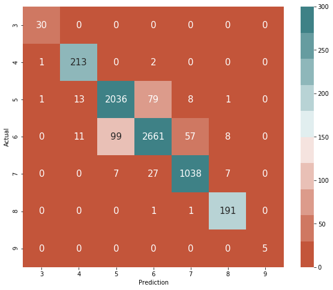

```python
%matplotlib inline
plt.figure(figsize=(10,8))

sns.heatmap(metrics.confusion_matrix(original_y, final_preds),
            vmin=0,
            vmax=300,
            annot=True,
            annot_kws={"fontsize":15},
            fmt="d",
            square=True,
            cmap=sns.diverging_palette(20, 200, n=10),
            yticklabels=targets,
            xticklabels=targets
           )

plt.xlabel('Prediction')
plt.ylabel('Actual')
```

```python
print(metrics.classification_report(original_y, final_preds))
```

```
              precision    recall  f1-score   support

           3       0.94      1.00      0.97        30
           4       0.90      0.99      0.94       216
           5       0.95      0.95      0.95      2138
           6       0.96      0.94      0.95      2836
           7       0.94      0.96      0.95      1079
           8       0.92      0.99      0.95       193
           9       1.00      1.00      1.00         5

    accuracy                           0.95      6497
   macro avg       0.94      0.98      0.96      6497
weighted avg       0.95      0.95      0.95      6497
```